# Image compression using SVD

References:

- Gilbert Strang, *Linear Algebra and Its Applications* 4e, section 6.3
- Tim Baumann, [“Image Compression with Singular Value Decomposition”](http://timbaumann.info/svd-image-compression-demo/)

Public-domain image from the [Biodiversity Heritage Library](https://www.flickr.com/photos/biodivlibrary/49060218173/in/album-72157711767640127/).

Singular value decomposition (SVD) factors a matrix into three components:

$$A = U S V^H$$

The middle $S$ is a diagonal matrix containing the square roots of the eigenvalues of $A^H A$ (or $A A^H$). Because $S$ is sorted from greatest $\sigma$ to least, we can zero out the tail end of $S$ as well as the corresponding columns of $U$ and $V$ to produce a lightweight set of matrices whose products approximate $A$.

Images are matrices, so this method is the basis of many widely used image-compression algorithms. Here, I give a practical demonstration of how SVD works and the level of quality one can expect when compressing a typical image.

First, we read in the image file. It’s a JPEG, so technically it’s already been compressed (you can even see some compression artifacts if you squint), but we won’t sweat it.

I cropped the image a bit at this stage to show its detail. The area we are working with is 1200 by 1300 pixels; these will be the eventual dimensions of $S$ in SVD. The array has an additional dimension of 3, corresponding to the image’s red, green, and blue channels.

```python
img = imread('linalg-img2.jpg')[500:1700,0:1300,:]
img.shape
```

```
(1200, 1300, 3)
```

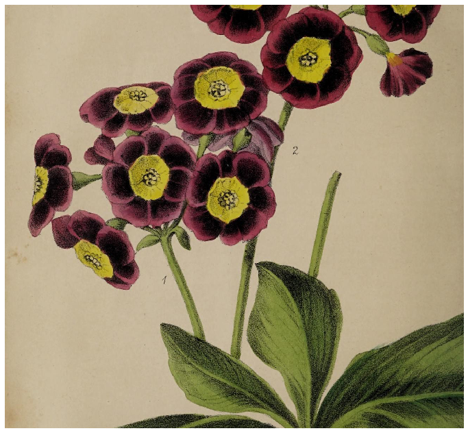

```python
plt.figure(figsize=(12,13))
plt.axis('off')
plt.imshow(img)
```

For now, I just want to work with one channel, so I will average the three together to produce a grayscale version of the image.

```python
img_bw = img.mean(axis=2)
```

[figure not shown]

```python
plt.figure(figsize=(12,13))
plt.axis('off')
plt.imshow(img_bw,cmap='gray')
```

Make a function that factors the image array using SVD and discards all but a specified portion of the entries. This function outputs three arrays, `left`,`sigma`, and `right`, that correspond to $U$, $S$, and $V^H$. That is, all you have to do is matrix-multiply them together to recover an approximation for the original array.

```python
def svd_prep(img, ratio=1):
    left, diag, right = np.linalg.svd(img)
    # Number of sigma values to keep
    keep = int(np.ceil(diag.size * ratio))
    # Discard unused columns and rows
    diag = diag[:keep]
    left = left[:,:keep]
    right = right[:keep]
    # Superimpose sigma onto a correctly shaped array of zeros
    sigma = np.zeros((keep, keep))
    for i in range(len(diag)):
        sigma[i,i] = diag[i]
    return(left, sigma, right)
```

Make sure the SVD is working; no compression yet.

```python
a, b, c = svd_prep(img_bw,1)
np.allclose((a @ b @ c),img_bw,rtol=1e-64)
```

```
True
```

Here are the compression ratios we’ll try.

```python
ratios = np.exp(np.arange(9) - 8)
ratios
```

```
array([3.35462628e-04, 9.11881966e-04, 2.47875218e-03, 6.73794700e-03,
       1.83156389e-02, 4.97870684e-02, 1.35335283e-01, 3.67879441e-01,
       1.00000000e+00])
```

Compress and reconstruct the images. Now `compressed_images` contains nine different approximations of the original array. This cell takes several seconds to run on my computer.

```python
compressed_images = []
for r in ratios:
    a, b, c = svd_prep(img_bw,r)
    # Divide by 255 because we aren't working with ints anymore;
    # matplotlib likes floats between 0 and 1
    b = b / 255
    compressed_images.append(a @ b @ c)
```

Let’s take a look at the compressed images. Note that substantial detail is preserved at only 13.5% of the filesize.

[figure not shown]

```python
plt.figure(figsize=(14,14))
plt.suptitle('Image compression by discarding small singular values in SVD',y=.9,size=16)
plt.subplots_adjust(hspace=0.1,wspace=0.05)
for i in range(9):
    plt.subplot(3,3,i+1)
    plt.imshow(compressed_images[i],cmap='gray')
    plt.title("SVD compression ratio: {}".format(np.round(ratios[i],decimals=4)),y=-.05,va="top")
    plt.axis('off')
```

Now, let’s see if we can do the same thing while preserving the color. First, we split the image into three arrays, one corresponding to each channel of the image. We perform SVD on these arrays separately, then recombine. We’ll use a 10% compression ratio this time, which yields decent results while still making the compression visible.

```python
img_r, img_g, img_b = img[:,:,0], img[:,:,1], img[:,:,2]
```

```python
compressed_channels=[]
for i in [img_r, img_g, img_b]:
    a, b, c = svd_prep(i,0.1)
    compressed_channels.append(a @ b @ c)
```

Recombining the channels.

```python
compressed_rgb = np.stack(compressed_channels,axis=2) / 255
compressed_rgb.shape
```

```
(1200, 1300, 3)
```

Let’s compare our compressed image to the original. Take a close look at the background if you can’t see the difference.

Matplotlib throws a warning because the approximate SVD decomposition has produced negative values in its approximation of $A$; clipping these to 0, which matplotlib does by default, is an acceptable remedy.

```
Clipping input data to the valid range for imshow with RGB data ([0..1] for floats or [0..255] for integers).
```

```
(-0.5, 1299.5, 1199.5, -0.5)
```

[figure not shown]

```python
plt.figure(figsize=(14,7))
plt.subplots_adjust(hspace=0,wspace=0.05)
plt.suptitle('SVD image compression using three channels',y=.9,size=14)

plt.subplot(1,2,1)
plt.imshow(compressed_rgb)
plt.title("SVD compression ratio: 0.1",y=-.04,va="top")
plt.axis('off')

plt.subplot(1,2,2)
plt.imshow(img)
plt.title("No compression",y=-.04,va="top")
plt.axis('off')
```

```python
!jupyter nbconvert svd.ipynb
```

```
[NbConvertApp] Converting notebook svd.ipynb to html
[NbConvertApp] Writing 3393870 bytes to svd.html
```